# COVID-19 Vaccinations by Country: Fair or Unfair?

### Tutorial by Bharath Hegde

# Introduction

COVID-19 has caused medical, emotional, psychological, and economic damage across the globe for almost two years at this point in time. Thankfully, COVID-19 vaccines are now available, and are being administered to people around the world. There are many different vaccines being used at the moment, and all tend to be highly effective at preventing symptoms, hospitalizations, and/or deaths.

However, one concern arises in the vaccination process. **Are vaccines being distributed to countries fairly?** In other words, are the countries that are/have suffering/suffered most from the pandemic getting enough supply, or is most of the supply going elsewhere?

Although it's important for everyone to get vaccinated, it's worth considering if **we can prioritize countries most in need, or at least provide them with more supply**.

In order to do that, this tutorial will guide you through the analysis of COVID-19 vaccination data. **We will determine what factors about a country make it more or less likely to have a better vaccination rate**.

# Part 0: Libraries

To collect data and perform the analysis, we need to rely on some Python libraries. Let's do all of the imports before continuing.

```python
import pandas as pd
import requests
import matplotlib.pyplot as plt
import numpy as np
import seaborn as sns
from sklearn.linear_model import LinearRegression
import statsmodels.api as sm
```

# Part 1: Data Collection and Cleanup

## Source

The most popular dataset on global COVID-19 cases and vaccinations appears to be the one compiled by Our World in Data.

This dataset works for us because it has a good amount of variables to work with per country: vaccinations per hundred, case counts, gdp per capita, death counts, etc. It is also heavily updated, and based on official sources from countries. [If you are interested, you may learn more about the dataset and what it provides here.](https://github.com/owid/covid-19-data/tree/master/public/data)

Citations:

- Hannah Ritchie, Esteban Ortiz-Ospina, Diana Beltekian, Edouard Mathieu, Joe Hasell, Bobbie Macdonald, Charlie Giattino, Cameron Appel, Lucas Rodés-Guirao and Max Roser (2020) - "Coronavirus Pandemic (COVID-19)". Published online at OurWorldInData.org. Retrieved from: 'https://ourworldindata.org/coronavirus' [Online Resource]
- Mathieu, E., Ritchie, H., Ortiz-Ospina, E. et al. *A global database of COVID-19 vaccinations. Nat Hum Behav (2021)*. https://doi.org/10.1038/s41562-021-01122-8

Download (latest data): https://raw.githubusercontent.com/owid/covid-19-data/master/public/data/latest/owid-covid-latest.csv

## Collection

Our World in Data provides their data as a regularly updated .csv file on GitHub. We'll simply download that file from our code, and then put it in a pandas data frame.

```python
# Load the .csv file into a pandas DataFrame
covid_df = pd.read_csv('https://raw.githubusercontent.com/owid/covid-19-data/master/public/data/latest/owid-covid-latest.csv')

# Display the data frame
covid_df
```

|  | iso_code | continent | location | last_updated_date | total_cases | new_cases | new_cases_smoothed | total_deaths | new_deaths | new_deaths_smoothed | ... | gdp_per_capita | extreme_poverty | cardiovasc_death_rate | diabetes_prevalence | female_smokers | male_smokers | handwashing_facilities | hospital_beds_per_thousand | life_expectancy | human_development_index |
| --- | --- | --- | --- | --- | --- | --- | --- | --- | --- | --- | --- | --- | --- | --- | --- | --- | --- | --- | --- | --- | --- |
| 0 | AFG | Asia | Afghanistan | 2021-05-15 | 63412.0 | 57.0 | 236.714 | 2733.0 | 3.0 | 7.143 | ... | 1803.987 | NaN | 597.029 | 9.59 | NaN | NaN | 37.746 | 0.500 | 64.83 | 0.511 |
| 1 | OWID_AFR | NaN | Africa | 2021-05-15 | 4681225.0 | 6802.0 | 8317.286 | 126088.0 | 240.0 | 278.714 | ... | NaN | NaN | NaN | NaN | NaN | NaN | NaN | NaN | NaN | NaN |
| 2 | ALB | Europe | Albania | 2021-05-15 | 131978.0 | 39.0 | 44.571 | 2429.0 | 2.0 | 2.571 | ... | 11803.431 | 1.1 | 304.195 | 10.08 | 7.100 | 51.200 | NaN | 2.890 | 78.57 | 0.795 |
| 3 | DZA | Africa | Algeria | 2021-05-15 | 125194.0 | 135.0 | 184.857 | 3366.0 | 6.0 | 6.429 | ... | 13913.839 | 0.5 | 278.364 | 6.73 | 0.700 | 30.400 | 83.741 | 1.900 | 76.88 | 0.748 |
| 4 | AND | Europe | Andorra | 2021-05-15 | 13510.0 | 0.0 | 14.857 | 127.0 | 0.0 | 0.000 | ... | NaN | NaN | 109.135 | 7.97 | 29.000 | 37.800 | NaN | NaN | 83.73 | 0.868 |
| ... | ... | ... | ... | ... | ... | ... | ... | ... | ... | ... | ... | ... | ... | ... | ... | ... | ... | ... | ... | ... | ... |
| 216 | WLF | Oceania | Wallis and Futuna | 2021-05-11 | NaN | NaN | NaN | NaN | NaN | NaN | ... | NaN | NaN | NaN | NaN | NaN | NaN | NaN | NaN | 79.94 | NaN |
| 217 | OWID_WRL | NaN | World | 2021-05-15 | 162521726.0 | 627518.0 | 690413.286 | 3369259.0 | 11649.0 | 12318.286 | ... | 15469.207 | 10.0 | 233.070 | 8.51 | 6.434 | 34.635 | 60.130 | 2.705 | 72.58 | 0.737 |
| 218 | YEM | Asia | Yemen | 2021-05-15 | 6538.0 | 15.0 | 10.857 | 1285.0 | 0.0 | 2.143 | ... | 1479.147 | 18.8 | 495.003 | 5.35 | 7.600 | 29.200 | 49.542 | 0.700 | 66.12 | 0.470 |
| 219 | ZMB | Africa | Zambia | 2021-05-15 | 92409.0 | 53.0 | 50.286 | 1260.0 | 0.0 | 0.429 | ... | 3689.251 | 57.5 | 234.499 | 3.94 | 3.100 | 24.700 | 13.938 | 2.000 | 63.89 | 0.584 |
| 220 | ZWE | Africa | Zimbabwe | 2021-05-15 | 38554.0 | 19.0 | 20.000 | 1582.0 | 0.0 | 0.857 | ... | 1899.775 | 21.4 | 307.846 | 1.82 | 1.600 | 30.700 | 36.791 | 1.700 | 61.49 | 0.571 |

221 rows × 59 columns

## Cleanup

Alright, we have global COVID-19 data now. To simplify our analysis, we need to consider which columns are the most significant for analysis purposes. Dealing with 59 columns is too much of a logistical and computational hassle. Let's drop the ones that don't help us.

Here are the columns we should keep:

**For reference purposes**

- `location`: it's good to keep this so we can look at the leading vaccinating countries and those who need more help

**Independent variables**

COVID-19 damage statistics

- `total_cases_per_million`: this is crucial to consider! Because vaccinated countries will likely have less new cases (due to the vaccines being effective), looking at the total historical cases of a country (i.e. considering cases before vaccines were available) is important!
- `total_deaths_per_million`: this is crucial to consider! Because vaccinated countries will likely have less new deaths (due to the vaccines being effective), looking at the total historical deaths of a country (i.e. considering deaths before vaccines were available) is important!
- `new_cases_smoothed_per_million`: 7-day moving average for new cases
- `new_deaths_smoothed_per_million`: 7-day moving average for new deaths

Other data

- `population`: do the most populated countries have better vaccination rates?
- `gdp_per_capita`: do richer countries have better vaccination rates?

**Dependent variable**

- `people_vaccinated_per_hundred`: % of people vaccinated with at least one dose.

These columns give us a reasonable set of independent and dependent variables to work with. There are others provided in the dataset, but for simplicity and relevancy's sake, these were chosen. You might also consider looking at the hospitalization and ICU data provided if you have time: those could be highly relevant as well.

Note that we're considering people who received at least one dose rather than full vaccinations. This is for a few reasons:

- One dose tends to provide a lot of protection on its own.
- It is reasonable to assume that people who received the first dose of a two-dose vaccine are already scheduled to get their second dose. In other words, the country already has enough supply to administer two doses.
- Many countries predominantly use one-dose vaccines instead of two-dose vaccines anyway.

Also, note that many of the independent variables and the dependent variable are standardized based on the population of the country. Countries with higher populations are more likely to have higher raw totals, but when considering damage from COVID-19, it has to be compared with population accounted for. That's why we're going to use per million and per 100 statistics.

```python
# Keep the most relevant columns
covid_df = covid_df[[
    'location', 'total_cases_per_million', 'new_cases_smoothed_per_million',
    'total_deaths_per_million', 'new_deaths_smoothed_per_million', 'population',
    'gdp_per_capita', 'people_vaccinated_per_hundred'
]]

# Rename the columns to make them shorter
covid_df.columns = [
    'country', 'cases_total_per_1m', 'cases_new_per_1m', 'deaths_total_per_1m',
    'deaths_new_per_1m', 'pop', 'gdp_per_capita', 'vax_per_100'
]

# Display the new frame
covid_df
```

|  | country | cases_total_per_1m | cases_new_per_1m | deaths_total_per_1m | deaths_new_per_1m | pop | gdp_per_capita | vax_per_100 |
| --- | --- | --- | --- | --- | --- | --- | --- | --- |
| 0 | Afghanistan | 1628.942 | 6.081 | 70.206 | 0.183 | 3.892834e+07 | 1803.987 | 1.15 |
| 1 | Africa | 3491.893 | 6.204 | 94.054 | 0.208 | 1.340598e+09 | NaN | 1.24 |
| 2 | Albania | 45860.727 | 15.488 | 844.048 | 0.894 | 2.877800e+06 | 11803.431 | 15.59 |
| 3 | Algeria | 2854.983 | 4.216 | 76.760 | 0.147 | 4.385104e+07 | 13913.839 | NaN |
| 4 | Andorra | 174852.779 | 192.288 | 1643.694 | 0.000 | 7.726500e+04 | NaN | 34.86 |
| ... | ... | ... | ... | ... | ... | ... | ... | ... |
| 216 | Wallis and Futuna | NaN | NaN | NaN | NaN | 1.124600e+04 | NaN | 38.11 |
| 217 | World | 20850.022 | 88.574 | 432.245 | 1.580 | 7.794799e+09 | 15469.207 | 8.97 |
| 218 | Yemen | 219.205 | 0.364 | 43.083 | 0.072 | 2.982597e+07 | 1479.147 | 0.06 |
| 219 | Zambia | 5026.611 | 2.735 | 68.538 | 0.023 | 1.838396e+07 | 3689.251 | 0.59 |
| 220 | Zimbabwe | 2593.971 | 1.346 | 106.439 | 0.058 | 1.486293e+07 | 1899.775 | 3.84 |

221 rows × 8 columns

Great! Now, let's simplify it further. For countries with missing data (`NaN`), we can't do any analysis, so let's just drop all rows with missing data.

```python
# Drop rows with any missing values
covid_df = covid_df.dropna()

# Display the data frame
covid_df
```

|  | country | cases_total_per_1m | cases_new_per_1m | deaths_total_per_1m | deaths_new_per_1m | pop | gdp_per_capita | vax_per_100 |
| --- | --- | --- | --- | --- | --- | --- | --- | --- |
| 0 | Afghanistan | 1628.942 | 6.081 | 70.206 | 0.183 | 3.892834e+07 | 1803.987 | 1.15 |
| 2 | Albania | 45860.727 | 15.488 | 844.048 | 0.894 | 2.877800e+06 | 11803.431 | 15.59 |
| 5 | Angola | 923.561 | 8.159 | 19.929 | 0.109 | 3.286627e+07 | 5819.495 | 1.78 |
| 6 | Antigua and Barbuda | 12672.576 | 13.129 | 336.982 | 1.459 | 9.792800e+04 | 21490.943 | 31.92 |
| 7 | Argentina | 72815.100 | 489.227 | 1554.415 | 10.149 | 4.519578e+07 | 18933.907 | 17.68 |
| ... | ... | ... | ... | ... | ... | ... | ... | ... |
| 215 | Vietnam | 42.244 | 1.272 | 0.370 | 0.001 | 9.733858e+07 | 6171.884 | 0.91 |
| 217 | World | 20850.022 | 88.574 | 432.245 | 1.580 | 7.794799e+09 | 15469.207 | 8.97 |
| 218 | Yemen | 219.205 | 0.364 | 43.083 | 0.072 | 2.982597e+07 | 1479.147 | 0.06 |
| 219 | Zambia | 5026.611 | 2.735 | 68.538 | 0.023 | 1.838396e+07 | 3689.251 | 0.59 |
| 220 | Zimbabwe | 2593.971 | 1.346 | 106.439 | 0.058 | 1.486293e+07 | 1899.775 | 3.84 |

144 rows × 8 columns

The last step is to remove the "World" row, because we want to perform the analysis based on the data of individual countries to compare them to each other, rather than comparing countries to the world totals and averages.

```python
# Drop the "World" row
covid_df = covid_df[covid_df['country'] != 'World']

# Display the data frame
covid_df
```

|  | country | cases_total_per_1m | cases_new_per_1m | deaths_total_per_1m | deaths_new_per_1m | pop | gdp_per_capita | vax_per_100 |
| --- | --- | --- | --- | --- | --- | --- | --- | --- |
| 0 | Afghanistan | 1628.942 | 6.081 | 70.206 | 0.183 | 38928341.0 | 1803.987 | 1.15 |
| 2 | Albania | 45860.727 | 15.488 | 844.048 | 0.894 | 2877800.0 | 11803.431 | 15.59 |
| 5 | Angola | 923.561 | 8.159 | 19.929 | 0.109 | 32866268.0 | 5819.495 | 1.78 |
| 6 | Antigua and Barbuda | 12672.576 | 13.129 | 336.982 | 1.459 | 97928.0 | 21490.943 | 31.92 |
| 7 | Argentina | 72815.100 | 489.227 | 1554.415 | 10.149 | 45195777.0 | 18933.907 | 17.68 |
| ... | ... | ... | ... | ... | ... | ... | ... | ... |
| 211 | Uzbekistan | 2879.304 | 10.201 | 19.929 | 0.021 | 33469199.0 | 6253.104 | 3.16 |
| 215 | Vietnam | 42.244 | 1.272 | 0.370 | 0.001 | 97338583.0 | 6171.884 | 0.91 |
| 218 | Yemen | 219.205 | 0.364 | 43.083 | 0.072 | 29825968.0 | 1479.147 | 0.06 |
| 219 | Zambia | 5026.611 | 2.735 | 68.538 | 0.023 | 18383956.0 | 3689.251 | 0.59 |
| 220 | Zimbabwe | 2593.971 | 1.346 | 106.439 | 0.058 | 14862927.0 | 1899.775 | 3.84 |

143 rows × 8 columns

Great! We now have a simplified set of data to work with. Relevant independent variables and dependent variables are present. It is time to move on to exploratory data analysis.

# Part 2: Exploratory Data Analysis

It's time to start looking at the level of inequality present, as well as potential correlations (what factors make the vaccination rate of a country better)?

Let's do a rough exploration of the data and then form some guesses, which we will later test using machine learning + hypothesis testing.

## Vaccination Rate Inequality

First, let's take a quick look at the amount of inequality there is with vaccinations between countries.

We can do this by analyzing the distribution of vaccination rates across the countries. To visualize the distribution, we can create a violin plot. This distribution might help reveal inequality: if we see that the majority of countries fall under low vaccination rates, and only a small proportion of the countries have good vaccination rates, inequality is present.

Note that violin plots use Kernel Density Estimation to figure out the distribution of the data. An alternative method of showing distributions is using histograms, but the choice of bins for the data can impact what the distribution looks like. We can avoid that problem using a violin plot. [You can read more about Kernel Density Estimation here if you're interested.](https://scikit-learn.org/stable/modules/density.html)

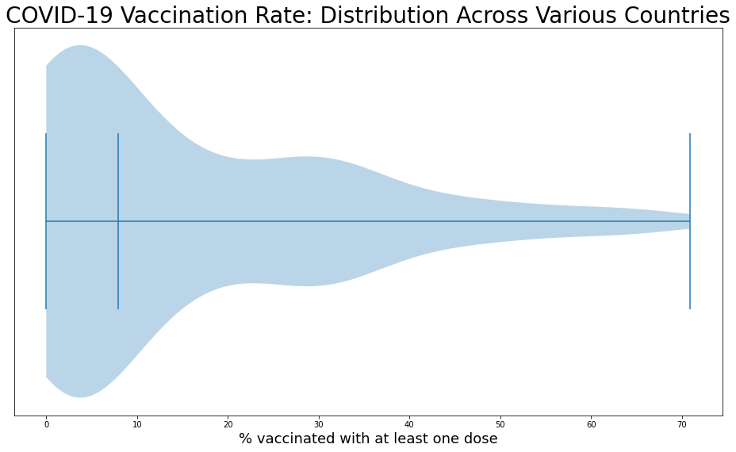

```python
# Create a violin plot showing the distribution of vaccination rates across countries
# -----------------------------------------------------------------------------------
fig, ax = plt.subplots(figsize=(16, 9))

# Create the violin plot
plt.violinplot(covid_df['vax_per_100'], showmedians=True, vert=False)

# Disable y-axis ticks: they are meaningless for this violin plot
ax.set_yticks([])

# Add labels
plt.xlabel('% vaccinated with at least one dose', fontsize=18)
plt.title('COVID-19 Vaccination Rate: Distribution Across Various Countries', fontsize=28)

# Show the graph
plt.show()
```

Unfortunately, the violin plot shows a heavy positive skew. The majority of countries are indeed dealing with low vaccination rates, with a few countries performing significantly better. The median is also shown on this plot, and you can see that it's around 8-9%, which is low. As you go towards the higher vaccination rates, the distribution narrows significantly.

**Based on this, there is heavy inequality in terms of the vaccination rates between countries.**

## ★ Factors That Correlate with Higher Vaccination Rates ★

Okay, we've proven that there is definitely inequality in vaccinations. Now, it's time for the main part of this analysis. We're going to guess what factors about a country make it more likely to have better vaccination rates.

### Scatter plotting

Let's begin by creating scatter plots that plot the vaccination rate versus each of the independent variables. This is an easy way to start looking for correlations.

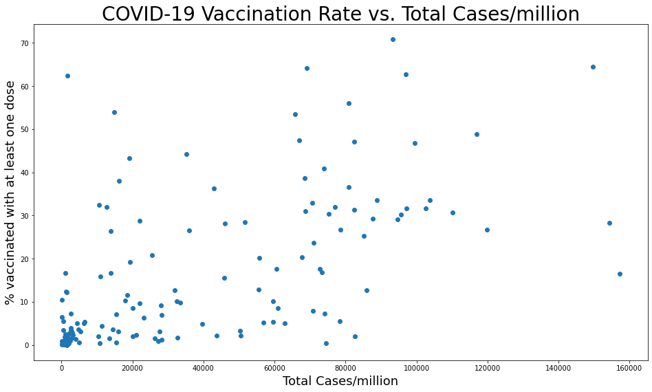

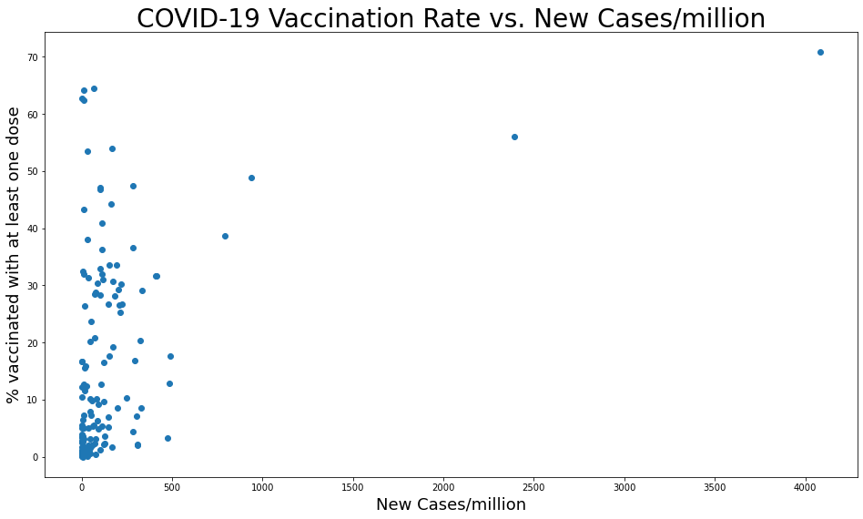

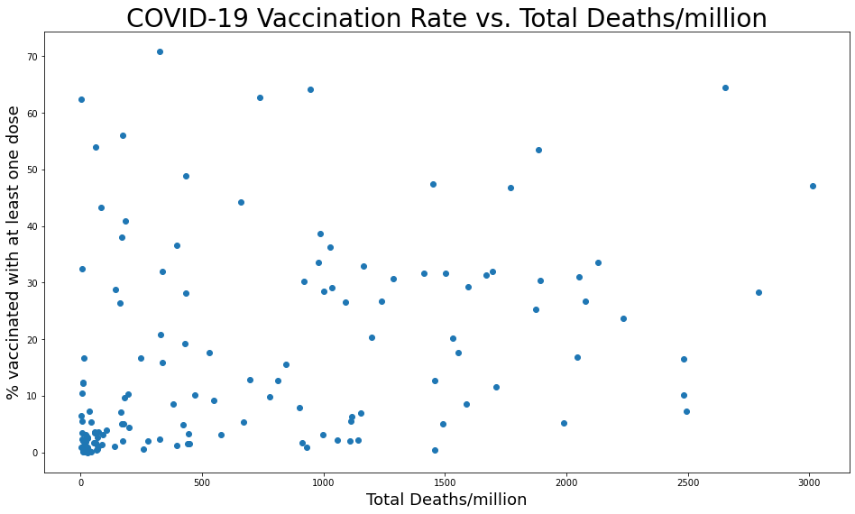

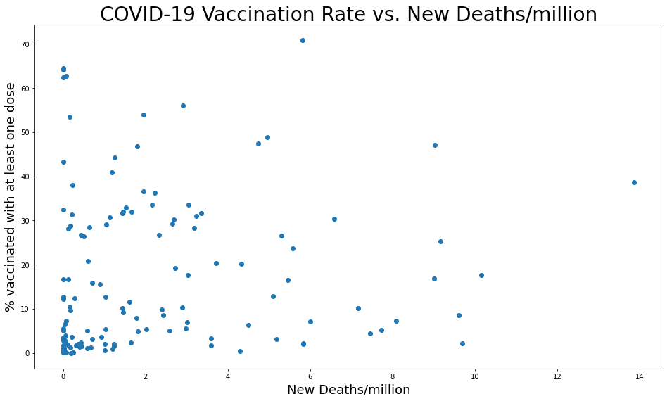

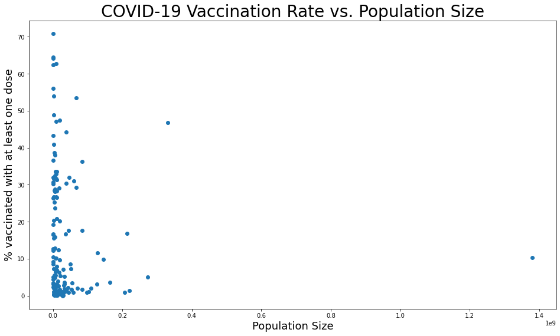

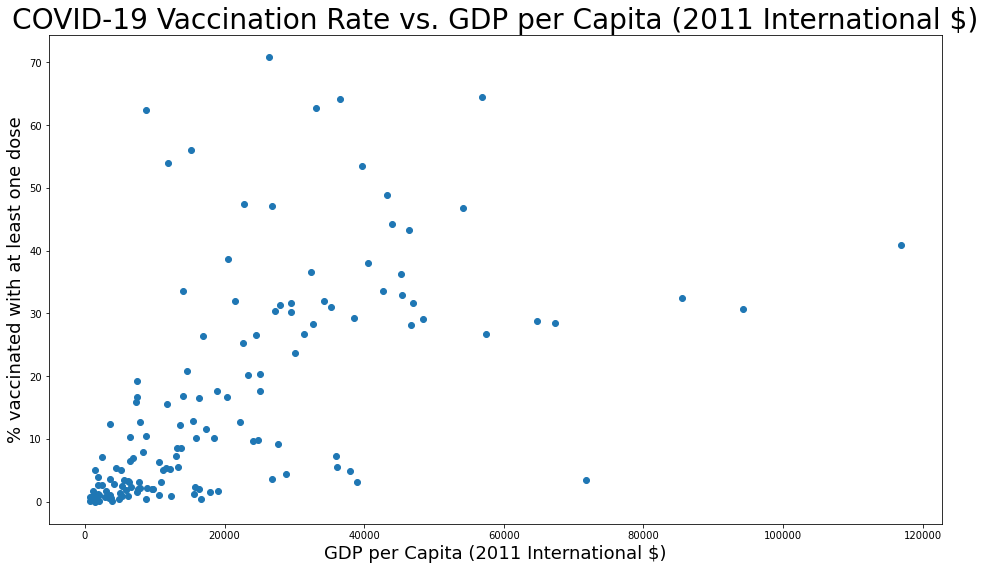

```python
# Create x-axis labels for each graph
x_labels = {
    'cases_total_per_1m': 'Total Cases/million',
    'cases_new_per_1m': 'New Cases/million',
    'deaths_total_per_1m': 'Total Deaths/million',
    'deaths_new_per_1m': 'New Deaths/million',
    'pop': 'Population Size',
    'gdp_per_capita': 'GDP per Capita (2011 International $)'
}

# Iterate through each independent variable
for x_var in x_labels.keys():
    fig, ax = plt.subplots(figsize=(16, 9))

    # Create the scatter plot
    plt.scatter(covid_df[x_var], covid_df['vax_per_100'])

    # Add labels
    plt.ylabel('% vaccinated with at least one dose', fontsize=18)
    plt.xlabel(x_labels[x_var], fontsize=18)
    plt.title(f'COVID-19 Vaccination Rate vs. {x_labels[x_var]}', fontsize=28)

    # Show the graph
    plt.show()
```

Let's think about each of these scatter plots. I will put a star (★) next to ones that we should look into further, and two stars (★★) next to especially promising ones.

- ★★ **Total cases/million**: we do generally see the vaccination rate increase as the total/cases per million does. There's a good chance there is a relationship.
- ★ **New cases/million**: due to outliers, this graph is scaled in a way that makes it hard to determine if there is a relationship. We'll come back to this one soon.
- **Total deaths/million**: there seems to be no clear relationship here, not even a weak one.
- **New deaths/million**: again, it seems there is no relationship present.
- ★ **Population size**: there's an outlier country with a huge population size, making the graph scale strangely. It's difficult to determine if there's a relationship right now. We'll come back to this one soon.
- ★★ **GDP per capita**: this seems to be the most promising relationship. There's definitely some kind of upwards trend that correlates vaccination rate to GDP per capita. We'll certainly keep an eye out on this one.

```python
# Drop the total deaths/million and new deaths/million columns.
# They don't appear to be helpful for us, since there is no clear relationship between
# them and vaccination rates.
covid_df = covid_df.drop(columns=['deaths_total_per_1m', 'deaths_new_per_1m'])
```

### Scatter plotting revised: dealing with outliers

As noted above, the new cases/million and population size graphs had outliers that made it difficult to notice relationships with vaccination rates.

We're going to have to redo those two graphs with the high outliers removed. A good way to do this is to simply remove values that reside in quantiles that are too high. [Read more about quantiles here](https://en.wikipedia.org/wiki/Quantile).

#### New cases/million

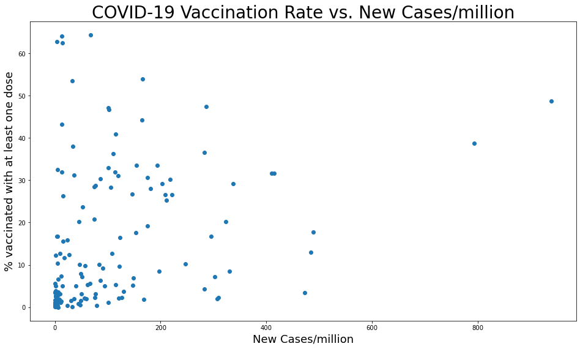

```python
# Exclude high outliers in the 99th+ quantile
newcases_high_quantile = covid_df['cases_new_per_1m'].quantile(0.99)

# Filter the data to remove outliers that are too high in terms of new cases
covid_df_newcases_fix = covid_df[covid_df['cases_new_per_1m'] < newcases_high_quantile]

# Retry the scatter plot...
fig, ax = plt.subplots(figsize=(16, 9))

# Create the scatter plot
plt.scatter(covid_df_newcases_fix['cases_new_per_1m'], covid_df_newcases_fix['vax_per_100'])

# Add labels
plt.ylabel('% vaccinated with at least one dose', fontsize=18)
plt.xlabel('New Cases/million', fontsize=18)
plt.title('COVID-19 Vaccination Rate vs. New Cases/million', fontsize=28)

# Show the graph
plt.show()
```

Okay, looks like there might be a very slight relationship here after all. You can kind of see the vaccination rate increase as the new cases per million increases, but not strongly. Compared to GDP per capita, this doesn't look very promising, but we'll investigate it.

#### Population size

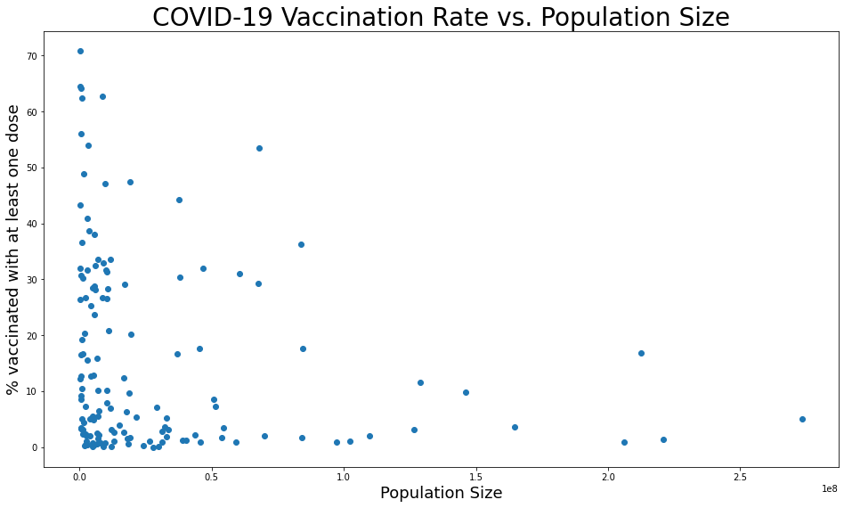

```python
# Exclude high outliers in the 99th+ quantile
pop_high_quantile = covid_df['pop'].quantile(0.99)

# Filter the data to remove outliers that are too high in terms of population size
covid_df_pop_fix = covid_df[covid_df['pop'] < pop_high_quantile]

# Retry the scatter plot...
fig, ax = plt.subplots(figsize=(16, 9))

# Create the scatter plot
plt.scatter(covid_df_pop_fix['pop'], covid_df_pop_fix['vax_per_100'])

# Add labels
plt.ylabel('% vaccinated with at least one dose', fontsize=18)
plt.xlabel('Population Size', fontsize=18)
plt.title('COVID-19 Vaccination Rate vs. Population Size', fontsize=28)

# Show the graph
plt.show()
```

There's no clear relationship here. If we really wanted to claim something based on this graph, larger population sizes might be correlated with lower vaccination rates. Logically speaking, that makes sense, since achieving larger vaccination rates with more people requires more doses. This relationship doesn't look promising at all based on the scatter plot, though. We'll still give it a chance.

### Heatmaps for correlations

We've identified some potential correlations using scatter plots and visually looking for trends. A more quantitative way of estimating a correlation is by using a correlation matrix heatmap.

This works by computing pairwise Pearson correlations between the columns. Essentially, this looks for linear relationships between columns. [Learn more about Pearson correlation coefficients here.](https://en.wikipedia.org/wiki/Pearson_correlation_coefficient)

This step might help us understand from a quantitative perspective how strong our relationships are. Also, we can perhaps drop some more columns from consideration.

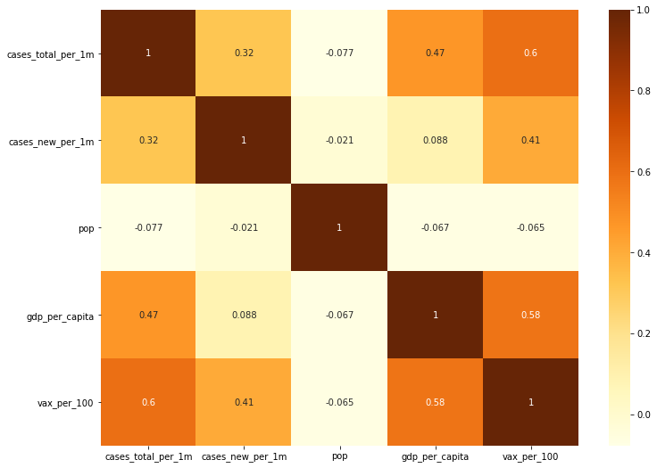

```python
# Create a heatmap of the Pearson correlation coefficient matrix
fig, ax = plt.subplots(figsize=(12, 9))

sns.heatmap(covid_df.corr(method='pearson'), annot=True, cmap='YlOrBr')
plt.show()
```

By looking at the last row, we can see how columns correlate to the vaccination rate.

Looks like Total Cases/million and GDP per Capita have moderately strong linear correlations with vaccination rate. They're both around 0.6, which isn't very strong but not weak either.

New cases/million has a weak linear correlation at 0.41.

Population size has a coefficient of -0.065. This number is close to zero and indicates that population size has no noteworthy linear relationship with vaccination rate. Based on the fact that the scatter plot didn't show any clear trends, it's not likely that a non-linear monotonic relationship exists either. It's not worth investigating further. Let's drop it from our data frame.

```python
# Drop the population column since it doesn't show any correlation with vaccination rates
covid_df = covid_df.drop(columns=['pop'])
```

## Summary

Using exploratory data analysis, our data frame now only has columns which we think have a reasonable linear correlation with vaccination rates. We've cut the work we have to do moving forward with machine learning. Let's look at our new data frame.

```python
# Show the new data frame
covid_df
```

|  | country | cases_total_per_1m | cases_new_per_1m | gdp_per_capita | vax_per_100 |
| --- | --- | --- | --- | --- | --- |
| 0 | Afghanistan | 1628.942 | 6.081 | 1803.987 | 1.15 |
| 2 | Albania | 45860.727 | 15.488 | 11803.431 | 15.59 |
| 5 | Angola | 923.561 | 8.159 | 5819.495 | 1.78 |
| 6 | Antigua and Barbuda | 12672.576 | 13.129 | 21490.943 | 31.92 |
| 7 | Argentina | 72815.100 | 489.227 | 18933.907 | 17.68 |
| ... | ... | ... | ... | ... | ... |
| 211 | Uzbekistan | 2879.304 | 10.201 | 6253.104 | 3.16 |
| 215 | Vietnam | 42.244 | 1.272 | 6171.884 | 0.91 |
| 218 | Yemen | 219.205 | 0.364 | 1479.147 | 0.06 |
| 219 | Zambia | 5026.611 | 2.735 | 3689.251 | 0.59 |
| 220 | Zimbabwe | 2593.971 | 1.346 | 1899.775 | 3.84 |

143 rows × 5 columns

# Part 3: Hypothesis Testing + Machine Learning

Nice, we now have three independent variables we want to test vaccination rates against: total cases per million, new cases per million, and GDP per capita. For all three, we're expecting an increase corresponds to higher vaccination rates.

## Significance/Hypothesis Testing

### Explanation

The next step is testing whether there could be a statistically significant relationship between our independent variables and dependent variables. This is the process of significance testing. If there is, we will proceed with making a machine learning model.

To do significance testing, let's use hypothesis testing. We'll have a **null hypothesis** that claims the following:

> There is no linear relationship between the total cases per million, new cases per million, and/or GDP per capita --> the vaccination rate of a country. You cannot predict the vaccination rate of a country in a statistically significant way based on these factors.

We'll also have an alternative hypothesis that claims:

> There is a linear relationship between the total cases per million, new cases per million, and/or GDP per capita --> the vaccination rate of a country. You can predict the vaccination rate of a country in a statistically significant way based on these factors.

To prove that our model has some predictive power, we need to be able to **reject the null hypothesis**. How do we determine whether we can reject the null hypothesis? We can calculate [p-values](https://en.wikipedia.org/wiki/P-value) and determine whether they are within a threshold we specify.

A p-value basically represents the probability that we'd see the values we get (the coefficients that correlate the independent variables to the dependent variables) if the null hypothesis were true.

**Let's use 0.05 as the threshold for p-values. If our p-values are under this, we'll assume that our model is statistically significant. Otherwise, we'll assume the null hypothesis should be accepted.**

### Approach

We can use `statsmodels`' [OLS (ordinary least squares)](https://en.wikipedia.org/wiki/Ordinary_least_squares) linear regression calculator on our data. This is not a machine learning approach, and is instead statistical. Ordinary least squares aims to minimize the sum of the squared differences between the predicted values by the regression and the actual values.

`statsmodels` is used over alternatives such as `scipy` because it supports multiple linear regression and calculates p-values for us.

`statsmodels` uses a two-tailed p-value computation and uses [the Wald test](https://en.wikipedia.org/wiki/Wald_test) to compute the t-statistic values.

```python
# Compute a linear regression for this data
X = covid_df[['cases_total_per_1m', 'cases_new_per_1m', 'gdp_per_capita']]
y = covid_df['vax_per_100']

sm_regression = sm.OLS(covid_df['vax_per_100'], sm.add_constant(X)).fit()

# Print a summary of the regression
print(sm_regression.summary())
```

```
                            OLS Regression Results
==============================================================================
Dep. Variable:            vax_per_100   R-squared:                       0.540
Model:                            OLS   Adj. R-squared:                  0.530
Method:                 Least Squares   F-statistic:                     54.29
Date:                Sun, 16 May 2021   Prob (F-statistic):           2.74e-23
Time:                        17:24:53   Log-Likelihood:                -555.38
No. Observations:                 143   AIC:                             1119.
Df Residuals:                     139   BIC:                             1131.
Df Model:                           3
Covariance Type:            nonrobust
======================================================================================
                         coef    std err          t      P>|t|      [0.025      0.975]
--------------------------------------------------------------------------------------
const                  1.4740      1.537      0.959      0.339      -1.564       4.512
cases_total_per_1m     0.0001   3.14e-05      4.651      0.000    8.39e-05       0.000
cases_new_per_1m       0.0115      0.003      4.455      0.000       0.006       0.017
gdp_per_capita         0.0004   5.76e-05      6.199      0.000       0.000       0.000
==============================================================================
Omnibus:                       66.547   Durbin-Watson:                   1.933
Prob(Omnibus):                  0.000   Jarque-Bera (JB):              233.582
Skew:                           1.769   Prob(JB):                     1.90e-51
Kurtosis:                       8.165   Cond. No.                     8.91e+04
==============================================================================

Notes:
[1] Standard Errors assume that the covariance matrix of the errors is correctly specified.
[2] The condition number is large, 8.91e+04. This might indicate that there are
strong multicollinearity or other numerical problems.
```

The p-values (in the `P>|t|` column) for our coefficients are all under 0.05, which means we can reject the null hypothesis. **All of the independent variables we were considering should have a statistically significant correlation with vaccination rates.** That's good news.

## Machine Learning with Multiple Linear Regression

### Approach and Alternatives

Let's begin making a linear regression model that incorporates all the independent variables as potential predictor values.

We could have used a different approach, such as logistic or polynomial regression, but:

- The Pearson correlation coefficients from Part 2 indicated a decent linear relationship between the independent variables and the dependent variable.
- Visually speaking, the scatter plots didn't strongly favor a non-linear monotonic relationship.

Note that by using linear regression, we're making a few assumptions (click the links to learn more):

- A linear relationship exists.
- The value of [residuals](https://www.statisticssolutions.com/homoscedasticity/) is independent of any other variable.
- [Homoscedasticity](https://www.statisticssolutions.com/homoscedasticity/) is present.
- The residuals are normally distributed.

We'll use `scikit-learn` to perform the regression. Alternatives such as `statsmodels` exist that don't rely on machine learning to do the regression, using statistical methods instead. However, we're interested in seeing what a machine learning model comes up with in this tutorial. [You can read more about scikit-learn's linear models here.](https://scikit-learn.org/stable/modules/linear_model.html)

### Method

`scikit-learn`'s LinearRegression model that we are using here continuously attempts to minimize the **residual sum of squares**.

Residuals are the difference between what the model predicts for a dependent variable, and and what it actually was from the data.

The residual sum of squares is the sum of all the residuals squared. [You can learn more about the concept here.](https://en.wikipedia.org/wiki/Residual_sum_of_squares)

In other words, `scikit-learn`'s LinearRegression model continuously tries to minimize the sum of squared differences between the vaccination rate its model predicts for these countries, and what the country's vaccination rate actually was. Eventually, by repeating this process, it can come up with a reasonably accurate model.

```python
# Fit a linear regression model to this data
X = covid_df[['cases_total_per_1m', 'cases_new_per_1m', 'gdp_per_capita']]
y = covid_df['vax_per_100']

covid_model = LinearRegression().fit(X, y)

# Print an equation form of the model
print('Linear regression model:')
print(f'{covid_model.coef_[0]} * cases_total_per_1m + \n\
{covid_model.coef_[1]} * cases_new_per_1m + \n\
{covid_model.coef_[2]} * gdp_per_capita + \n\
{covid_model.intercept_}')

# Create predictions of vaccination rates for each country using the model
covid_df['vax_per_100_prediction'] = covid_model.predict(X)

# Compute the residuals
covid_df['residual'] = covid_df['vax_per_100_prediction'] - covid_df['vax_per_100']

# Show the data frame
covid_df
```

```
Linear regression model:
0.0001459136047569883 * cases_total_per_1m +
0.011548680327619782 * cases_new_per_1m +
0.0003568321790548227 * gdp_per_capita +
1.4739889948385656
```

|  | country | cases_total_per_1m | cases_new_per_1m | gdp_per_capita | vax_per_100 | vax_per_100_prediction | residual |
| --- | --- | --- | --- | --- | --- | --- | --- |
| 0 | Afghanistan | 1628.942 | 6.081 | 1803.987 | 1.15 | 2.425622 | 1.275622 |
| 2 | Albania | 45860.727 | 15.488 | 11803.431 | 15.59 | 12.556403 | -3.033597 |
| 5 | Angola | 923.561 | 8.159 | 5819.495 | 1.78 | 3.779558 | 1.999558 |
| 6 | Antigua and Barbuda | 12672.576 | 13.129 | 21490.943 | 31.92 | 11.143373 | -20.776627 |
| 7 | Argentina | 72815.100 | 489.227 | 18933.907 | 17.68 | 24.504856 | 6.824856 |
| ... | ... | ... | ... | ... | ... | ... | ... |
| 211 | Uzbekistan | 2879.304 | 10.201 | 6253.104 | 3.16 | 4.243235 | 1.083235 |
| 215 | Vietnam | 42.244 | 1.272 | 6171.884 | 0.91 | 3.697170 | 2.787170 |
| 218 | Yemen | 219.205 | 0.364 | 1479.147 | 0.06 | 2.037985 | 1.977985 |
| 219 | Zambia | 5026.611 | 2.735 | 3689.251 | 0.59 | 3.555469 | 2.965469 |
| 220 | Zimbabwe | 2593.971 | 1.346 | 1899.775 | 3.84 | 2.545930 | -1.294070 |

143 rows × 7 columns

### Residuals: Distribution

Okay, now we need to look at the distribution of our residuals. Remember, our linear regression model makes a few assumptions about residuals. One of them is that the residuals follow a normal distribution. We need to verify that the residuals we have do indeed have a normal distribution, otherwise our linear regression model isn't applicable.

Once again, we can use a violin plot to show the distribution.

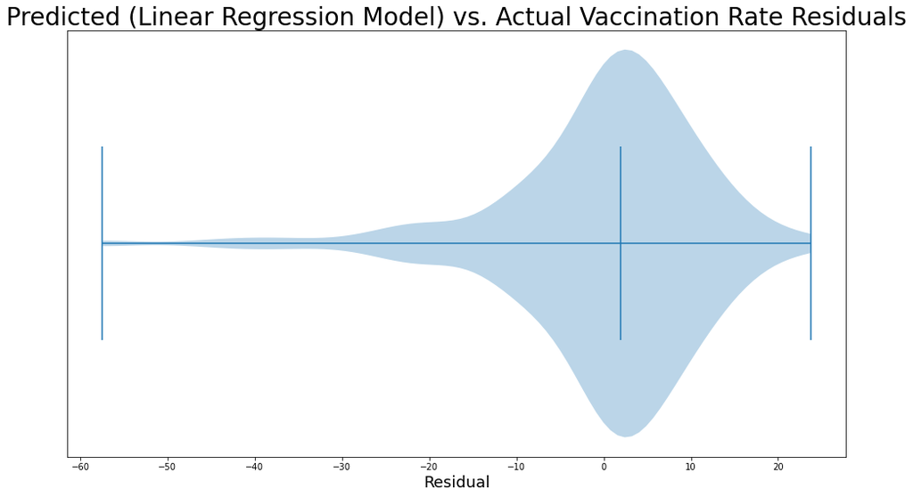

```python
# Create a violin plot showing the distribution of residuals
# -----------------------------------------------------------------------------------
fig, ax = plt.subplots(figsize=(16, 9))

# Create the violin plot
plt.violinplot(covid_df['residual'], showmedians=True, vert=False)

# Disable y-axis ticks: they are meaningless for this violin plot
ax.set_yticks([])

# Add labels
plt.xlabel('Residual', fontsize=18)
plt.title('Predicted (Linear Regression Model) vs. Actual Vaccination Rate Residuals', fontsize=28)

# Show the graph
plt.show()
```

At first glance, the distribution looks like it's not a normal distribution due to the negative skew.

However, consider the left side of the distribution. We're getting residuals such as -50 or even almost -60 which are **significantly different from the majority of the data**. Plus, there's not many of them, because this side of the distribution is narrow. It's very reasonable to say that these figures are outliers that don't represent the data well.

If we consider those countries to be outliers, let's remove them from the data before creating the plot. We can use the quantile method again, excluding countries with residuals below the 2nd quantile. That should be pretty conservative and not affect the distribution too much.

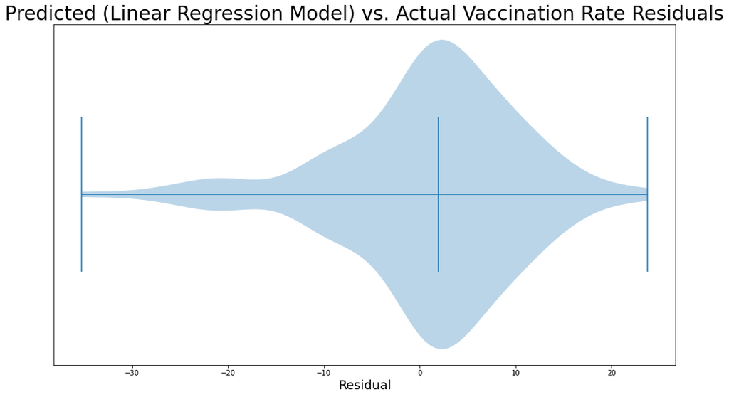

```python
residual_low_quantile = covid_df['residual'].quantile(0.02)

# Filter the data to remove outliers that are too low in terms of residuals
covid_df_residual_fix = covid_df[covid_df['residual'] > residual_low_quantile]

fig, ax = plt.subplots(figsize=(16, 9))

# Create the violin plot
plt.violinplot(covid_df_residual_fix['residual'], showmedians=True, vert=False)

# Disable y-axis ticks: they are meaningless for this violin plot
ax.set_yticks([])

# Add labels
plt.xlabel('Residual', fontsize=18)
plt.title('Predicted (Linear Regression Model) vs. Actual Vaccination Rate Residuals', fontsize=28)

# Show the graph
plt.show()
```

This looks pretty close to a normal distribution. Most likely, it's good enough for us to say that **the assumption of residuals being normally distributed is satisfied**.

## Summary

It looks like we have a valid linear regression model:

```
0.0001459136047569883 * cases_total_per_1m +
0.011548680327619782 * cases_new_per_1m +
0.0003568321790548227 * gdp_per_capita +
1.4739889948385656
```

It seems that all three are statistically significant predictors for which countries have the highest vaccination rates. They have linear relationships with positive correlations. The slope values are fairly low.

**Interpretation of the slopes**:

- Countries tend to have a 0.0001459136047569883% higher vaccination rate for every total case per one million people.
- Countries tend to have a 0.011548680327619782% higher vaccination rate for every new case per one million people.
- Countries tend to have a 0.0003568321790548227% higher vaccination rate for every $1 of GDP per capita (2011 international dollars)

# Conclusion

## Is there inequality between countries when it comes to vaccination rates?

Yes, undoubtedly. The violin plot produced during the exploratory data analysis indicates that vaccination rates are positively skewed. A small minority of countries have good vaccination rates while the majority are at low vaccination rates.

## What factors about a country correlate with vaccination rates?

The total cases per one million, new cases per one million, and GDP per capita have statistically significant linear relationships with vaccination rates. The countries with higher vaccination rates tend to have higher values for these data points as well.

## Are countries getting vaccines fairly?

The total cases per one million and new cases per one million factors have a positive trend with vaccination rates. This indicates that countries that suffered from or are currently suffering from higher case counts tend to have better vaccination rates.

That seems pretty fair, and indicates that the countries that need vaccines the most (at least based on this data) are getting a good supply of them relative to other countries.

However, GDP per capita also plays a significant part in vaccination rates based on my analysis. This indicates that more wealthy countries have a better supply and/or distribution of vaccines relative to other countries. This is something that should be remedied.

## What you learned

In this tutorial, you went through the process of:

- Collecting data
- Cleaning it up
- Exploring it to find potential trends
- Testing the statistical significance of those trends using hypothesis testing
- Using machine learning with multiple linear regression to calculate the coefficients of the linear regression representing the trends

As a challenge, try re-doing the analysis using more socioeconomic factors, population density, geographical size, or hospitalization and ICU data for independent variables.

Thanks for reading this tutorial, and remember to get your COVID-19 vaccine if you haven't already, and if it's available in your area.